# Large Screen Analysis with cellmig

# 4 Partial pooling enables robust inferrence and controls false positives

## 4.1 What is partial pooling?

The key advantage of hierarchical modeling is **partial pooling**: treatment effects with high uncertainty are shrunk toward more stable estimates, borrowing strength from related groups in the data hierarchy.

| Level | What is pooled | From → To | Why it matters |
| --- | --- | --- | --- |
| **1. Cell → Well** | Individual cell velocities | Cells → Well mean ($\mu_w$) | Stabilizes well estimates when few cells are tracked |
| **2. Well → Plate** | Well-specific treatment effects | Wells → Plate-specific effect ($\gamma_{pt}$) | Accounts for technical variability between wells |
| **3. Plate → Treatment** | Plate-specific treatment effects | Plates → Overall treatment effect ($\delta_t$) | Accounts for biological variability between replicates |
| **4. Treatment → Population** | Overall treatment effects | All treatments → population of treatments: N(0, $\sigma_\delta$) | Controls false positives via shrinkage toward null |

When data is noisy or sparse, the population-level information dominates (strong shrinkage). When data is abundant and consistent, the group-specific data dominates (weak shrinkage).

**In this vignette:** We focus on the top level (treatment → population), where overall treatment effects ($\delta_t$) are shrunk toward zero. This is the mechanism that automatically controls false positives in large screens without requiring explicit multiple testing correction.

## 4.2 Visualizing shrinkage

We compare effect estimates from low-noise data (y-axis, our reference) against high-noise and very-high-noise data (x-axes):

```r
# Extract posterior summaries for treatment effects
dtl <- cl$posteriors$delta_t
colnames(dtl) <- paste0(colnames(dtl), "_l")
dth <- ch$posteriors$delta_t
colnames(dth) <- paste0(colnames(dth), "_h")
dtvh <- cvh$posteriors$delta_t
colnames(dtvh) <- paste0(colnames(dtvh), "_vh")
dt <- cbind(dth, dtvh, dtl)
```

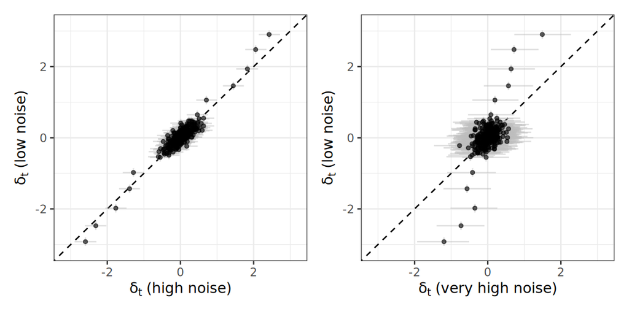

```r
p1 <- ggplot(data = dt)+
    geom_abline(slope = 1, intercept = 0, linetype = "dashed")+
    geom_errorbar(aes(x = mean_h, y = mean_l, ymin = X2.5._l, ymax = X97.5._l),
                  col = "gray", alpha = 0.5)+
    geom_errorbar(aes(x = mean_h, y = mean_l, xmin = X2.5._h, xmax = X97.5._h),
                  col = "gray", alpha = 0.5)+
    geom_point(aes(x = mean_h, y = mean_l), size = 1, alpha = 0.6)+
    scale_x_continuous(name = expression(delta[t]*" (high noise)"),
                       limits = c(-3.15, 3.15))+
    scale_y_continuous(name = expression(delta[t]*" (low noise)"),
                       limits = c(-3.15, 3.15))+
    theme_bw(base_size = 10)

p2 <- ggplot(data = dt)+
    geom_abline(slope = 1, intercept = 0, linetype = "dashed")+
    geom_errorbar(aes(x = mean_vh, y = mean_l, ymin = X2.5._l, ymax = X97.5._l),
                  col = "gray", alpha = 0.5)+
    geom_errorbar(aes(x = mean_vh, y = mean_l, xmin = X2.5._vh, xmax = X97.5._vh),
                  col = "gray", alpha = 0.5)+
    geom_point(aes(x = mean_vh, y = mean_l), size = 1, alpha = 0.6)+
    scale_x_continuous(name = expression(delta[t]*" (very high noise)"),
                       limits = c(-3.15, 3.15))+
    scale_y_continuous(name = expression(delta[t]*" (low noise)"),
                       limits = c(-3.15, 3.15))+
    theme_bw(base_size = 10)

p1 | p2
```

## 4.3 Interpreting the shrinkage plot

| Pattern | What It Means | Why It Matters |
| --- | --- | --- |
| **Points near diagonal** | Effects estimated similarly across noise levels | Strong, well-supported effects—reliable regardless of noise |
| **Points pulled toward zero on x-axis** | Weak effects in high-noise data shrunk toward null | Partial pooling prevents over-interpreting noisy data |
| **Wider error bars on x-axis** | Higher uncertainty in high-noise conditions | Model correctly reports less confidence when data is noisy |

This shrinkage mechanism **automatically controls false positives** without requiring explicit multiple testing correction. Treatments with weak evidence are conservatively estimated near zero, while strong effects remain detectable.

# 5 Prioritizing compounds for follow-up

In large screens, you need to prioritize which compounds to validate experimentally. We recommend using a **volcano-like plot** combining effect size ($\rho'$) and probability of effect ($\pi$).

## 5.1 Understanding the metrics

Before prioritizing, it’s important to understand what these metrics represent:

### 5.1.1 Effect Size ($\rho'$): magnitude of change

The parameter $\rho'$ represents the **fold-change** in migration velocity effects ($\delta_t$) between two treatment groups (exponentiated from log-scale):

- $\rho' = 1$: No effect (null hypothesis; equal velocity between groups)
- $\rho' < 1$: Reduced migration (e.g., $\rho' = 0.7$ indicates a 30% reduction in velocity)
- $\rho' > 1$: Increased migration (e.g., $\rho' = 1.5$ indicates a 50% increase in velocity)

**Interpreting magnitude:** The biological relevance of effect size depends on your system and research question. As a general guide:

| Effect Size ($\rho'$) | Interpretation | Considerations |
| --- | --- | --- |
| 0.9 – 1.1 | Very small change | May be statistically detectable but |
| biologically trivial |  |  |
| 0.7 – 0.9 or 1.1 – 1.3 | Small to moderate | Often biologically meaningful; |
| context-dependent |  |  |
| 0.5 – 0.7 or 1.3 – 2.0 | Moderate to large | Clear phenotypic impact; |
| typically worth follow-up |  |  |
| < 0.5 or > 2.0 | Large effect | Strong phenotypic change; high priority |
| if confident |  |  |

**Important:** These ranges are illustrative, not prescriptive. In some biological contexts, a 10% change may be highly meaningful (e.g., subtle signaling perturbations), while in others, only dramatic changes warrant attention.

### 5.1.2 Probability of effect ($\pi$): confidence in the estimate

The parameter $\pi$ quantifies the **probability that a true difference exists** between treatments, based on the posterior distribution:

- $\pi \approx 0$: No evidence for a difference (posterior distribution of $\rho'$ centered on $\rho'=1$ with equal density on either side)
- $\pi \approx 1$: Strong evidence for a difference (posterior distribution of $\rho'$ clearly on left or right side of $\rho'=1$)

Unlike p-values, $\pi$ is a direct probability statement about the effect, making it more intuitive for decision-making. However, it should always be considered alongside effect size magnitude.

## 5.2 Creating a prioritization plot

Visualizing both metrics together helps identify compounds that combine meaningful effect sizes with high confidence:

```r
# Get pairwise comparisons against control
pairs <- get_pairs(x = ch, exponentiate = TRUE)$ds
```

```
FALSE Warning in get_pairs(x = ch, exponentiate = TRUE): groups not specified, we
FALSE will use all groups
```

```r
pairs$contrast <- apply(X = pairs[,c("group_x", "group_y")], MARGIN = 1,
                        FUN = function(x) {
    return(paste0(sort(x), collapse = "|"))
})
pairs_unique <- pairs[duplicated(pairs$contrast)==F,]
```

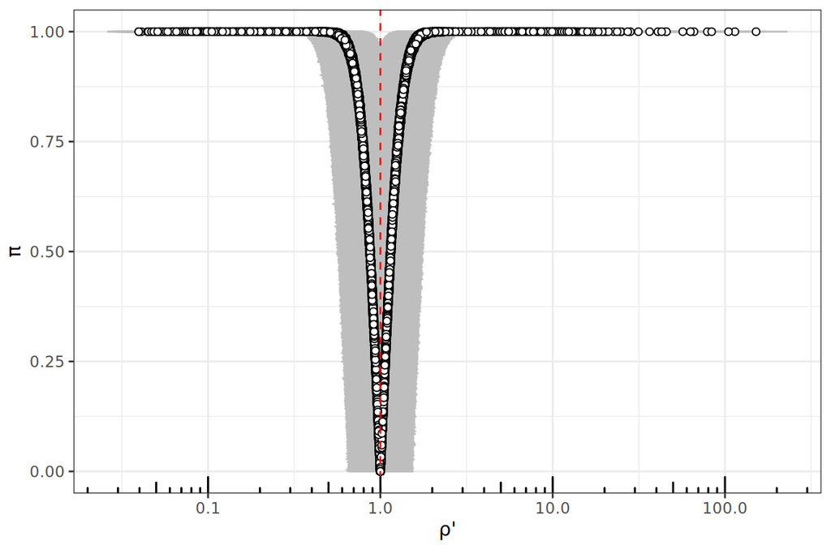

```r
ggplot(data = pairs_unique)+
    geom_errorbar(aes(x = exp(rho_M), y = pmax, xmin = exp(rho_L95),
                      xmax = exp(rho_H95)), col = "gray")+
    geom_point(aes(x = exp(rho_M), y = pmax), size = 1.5, shape = 21,
               fill = "white", col = "black")+
    geom_vline(xintercept = 1, linetype = "dashed", col = "red")+
    ylab(label = expression(pi))+
    xlab(label = expression(rho*"'"))+
    scale_x_log10()+
    annotation_logticks(base = 10, sides = "b")
```

The plot shows effect size ($\rho'$, x-axis) versus confidence ($\pi$, y-axis). The vertical dashed line at $\rho'=1$ indicates the null effect (no change).

## 5.3 A flexible prioritization framework

Rather than applying rigid thresholds, we recommend considering **both metrics jointly** when prioritizing compounds. The following framework can guide decision-making.

### 5.3.1 Key principles for decision-making

1. **High** $\pi$ + $\rho'$ >> 1 or $\rho'$ << 1: Best candidates—confident and biologically meaningful
2. **High** $\pi$ + Small $\rho'$: Statistically real but assess biological relevance before investing resources
3. **Low** $\pi$: Lower priority

### 5.3.2 Adjusting for your context

The appropriate prioritization strategy depends on several factors:

- **Screen size**: Larger screens may require higher $\pi$ to manage validation workload
- **Validation cost**: Expensive follow-up assays warrant higher confidence ($\pi > 0.99$)
- **Biological context**: Some systems expect subtle effects; others require dramatic changes
- **Discovery stage**: Early exploration may accept lower $\pi$ for leads; late-stage validation requires high confidence
- **Effect direction**: You may prioritize suppressors over enhancers (or vice versa) based on your biological question

## 5.4 Exporting prioritized hits

The following example demonstrates one approach to extracting and ranking candidates. **Adjust the filtering criteria based on your specific needs:**

```r
# Sort by magnitude of effect size (largest effects first)
pairs_unique <- pairs_unique[order(abs(pairs_unique$rho_M), decreasing = TRUE), ]

# Example: Filter for high-confidence hits
# Note: Thresholds should be adjusted based on your screen's characteristics
high_confidence <- pairs_unique[pairs_unique$pmax >= 0.99, ]

# View top candidates
knitr::kable(head(high_confidence[, c("group_x", "group_y", "rho_M",
                                      "rho_L95", "rho_H95", "pmax")], 20),
             row.names = FALSE, digits = 2)
```

| group_x | group_y | rho_M | rho_L95 | rho_H95 | pmax |
| --- | --- | --- | --- | --- | --- |
| 311\|X | 306\|X | 5.02 | 4.61 | 5.44 | 1 |
| 311\|X | 305\|X | 4.74 | 4.31 | 5.14 | 1 |
| 310\|X | 306\|X | 4.65 | 4.23 | 5.06 | 1 |
| 309\|X | 306\|X | 4.43 | 4.03 | 4.85 | 1 |
| 310\|X | 305\|X | 4.37 | 3.93 | 4.75 | 1 |
| 311\|X | 304\|X | 4.19 | 3.78 | 4.61 | 1 |
| 309\|X | 305\|X | 4.14 | 3.73 | 4.55 | 1 |
| 308\|X | 306\|X | 4.04 | 3.63 | 4.47 | 1 |
| 310\|X | 304\|X | 3.82 | 3.43 | 4.25 | 1 |
| 311\|X | 303\|X | 3.82 | 3.42 | 4.22 | 1 |
| 308\|X | 305\|X | 3.76 | 3.37 | 4.17 | 1 |
| 311\|X | 302\|X | 3.71 | 3.32 | 4.13 | 1 |
| 309\|X | 304\|X | 3.60 | 3.21 | 4.02 | 1 |
| 310\|X | 303\|X | 3.45 | 3.04 | 3.85 | 1 |
| 310\|X | 302\|X | 3.34 | 2.93 | 3.74 | 1 |
| 307\|X | 306\|X | 3.31 | 2.90 | 3.73 | 1 |
| 306\|X | 175\|X | -3.23 | -3.65 | -2.83 | 1 |
| 306\|X | 241\|X | -3.23 | -3.65 | -2.82 | 1 |
| 309\|X | 303\|X | 3.22 | 2.81 | 3.65 | 1 |
| 308\|X | 304\|X | 3.21 | 2.80 | 3.61 | 1 |

```r
# compute rho' = exp(rho)
high_confidence$rho_prime_M <- exp(high_confidence$rho_M)
high_confidence$rho_prime_L95 <- exp(high_confidence$rho_L95)
high_confidence$rho_prime_H95 <- exp(high_confidence$rho_H95)

# View top candidates
knitr::kable(head(high_confidence[, c("group_x", "group_y",
                                      "rho_M", "rho_L95", "rho_H95",
                                      "rho_prime_M", "rho_prime_L95",
                                      "rho_prime_H95","pmax")], 20),
             row.names = FALSE, digits = 2)
```

| group_x | group_y | rho_M | rho_L95 | rho_H95 | rho_prime_M | rho_prime_L95 | rho_prime_H95 | pmax |
| --- | --- | --- | --- | --- | --- | --- | --- | --- |
| 311\|X | 306\|X | 5.02 | 4.61 | 5.44 | 151.49 | 100.20 | 230.31 | 1 |
| 311\|X | 305\|X | 4.74 | 4.31 | 5.14 | 114.16 | 74.26 | 171.51 | 1 |
| 310\|X | 306\|X | 4.65 | 4.23 | 5.06 | 104.79 | 68.67 | 157.43 | 1 |
| 309\|X | 306\|X | 4.43 | 4.03 | 4.85 | 83.66 | 56.17 | 127.82 | 1 |
| 310\|X | 305\|X | 4.37 | 3.93 | 4.75 | 78.97 | 50.88 | 115.41 | 1 |
| 311\|X | 304\|X | 4.19 | 3.78 | 4.61 | 66.10 | 43.92 | 100.27 | 1 |
| 309\|X | 305\|X | 4.14 | 3.73 | 4.55 | 63.04 | 41.62 | 94.53 | 1 |
| 308\|X | 306\|X | 4.04 | 3.63 | 4.47 | 56.91 | 37.73 | 87.62 | 1 |
| 310\|X | 304\|X | 3.82 | 3.43 | 4.25 | 45.72 | 30.95 | 70.01 | 1 |
| 311\|X | 303\|X | 3.82 | 3.42 | 4.22 | 45.41 | 30.44 | 68.22 | 1 |
| 308\|X | 305\|X | 3.76 | 3.37 | 4.17 | 42.88 | 29.11 | 65.03 | 1 |
| 311\|X | 302\|X | 3.71 | 3.32 | 4.13 | 40.82 | 27.53 | 62.04 | 1 |
| 309\|X | 304\|X | 3.60 | 3.21 | 4.02 | 36.50 | 24.83 | 55.71 | 1 |
| 310\|X | 303\|X | 3.45 | 3.04 | 3.85 | 31.41 | 20.85 | 47.20 | 1 |
| 310\|X | 302\|X | 3.34 | 2.93 | 3.74 | 28.24 | 18.67 | 41.98 | 1 |
| 307\|X | 306\|X | 3.31 | 2.90 | 3.73 | 27.26 | 18.16 | 41.49 | 1 |
| 306\|X | 175\|X | -3.23 | -3.65 | -2.83 | 0.04 | 0.03 | 0.06 | 1 |
| 306\|X | 241\|X | -3.23 | -3.65 | -2.82 | 0.04 | 0.03 | 0.06 | 1 |
| 309\|X | 303\|X | 3.22 | 2.81 | 3.65 | 25.07 | 16.67 | 38.65 | 1 |
| 308\|X | 304\|X | 3.21 | 2.80 | 3.61 | 24.83 | 16.43 | 36.87 | 1 |

## 5.5 Validate by visualizing raw data

Before committing resources to experimental validation, we recommend inspecting the raw velocity distributions for top candidates. This helps verify that:

1. **Effects are consistent** across biological replicates (plates)
2. **No plate-specific artifacts** are driving the signal
3. **Velocity distributions** appear reasonable (not skewed by outliers or tracking errors)

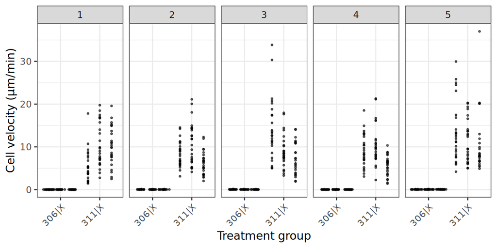

[output not shown]

```r
# Extract processed data from fitted model
d <- ch$data$proc_x

# Select the top-ranked comparison for visualization
top_hit <- high_confidence[1, ]

# Filter data for the two groups being compared
d <- d[d$group_id %in% c(top_hit$group_id_x, top_hit$group_id_y), ]

# Plot raw velocities by treatment group, faceted by plate
ggplot(data = d)+
    facet_wrap(~plate_id, nrow = 1)+
    geom_sina(aes(x = group, y = v, group = well), size = 0.5, alpha = 0.6)+
    ylab("Cell velocity (µm/min)")+
    xlab("Treatment group")+
    theme_bw(base_size = 10)+
    theme(axis.text.x = element_text(angle = 45, hjust = 1))
```